# 08 교락법과 일부실시법

## 08.01. 계획의 개념

- 요인배치법은 각 요인들의 주효과와 상호작용효과를 모두 구할 수 있따는 장점이 있지만

  요인의 수가 늘면, 실험의 크기가 급속히 증가

  $\rightarrow$ 실험비용 증가, 실험오차 증가
- 실험의 횟수를 늘리지 않고, 실험오차가 작아지도록, 실험 전체를 몇 개의 블록으로 나누어 배치시킴으로서 동일한 환경 내에서 실험의 횟수를 되도록 적게 하도록 고안한 **교락법**
- **고차원 상호작용효과 : 3요인 이상의 상호작용효과**, 일반적으로 유의하지 않으며, 해석이 어려움

  따라서 만약 주효과와 일부 상호작용효과에만 관심이 있다면 전체 처리조합중 일부만 실험함으로서 실험의 크기를 줄이는 **일부실시법**

## 08.02. 교락법

- **요인의 수가 많은 경우에 사용**

#### $2^3$요인배치법 예시

- 처리조합 8개 ((1), a, b, ab, c, ac, bc, abc)중 하루(동질적인 환경하)에 4번만 실시할 수 없어서, 2일에 걸쳐 실험을 할 경우

  **[블록 1: a, ab, ac ,abc / 블록 2 : (1), b, c, bc]**

  **A의 주효과 : $A = {1\over4}(a + ab+ ac+ abc - (1) - b- c- bc)$**

  **블록효과 : 두 블록에서의 평균 차이 = ${1\over4}(a+ab+ac+abc-(1)-b-c-bc)$가 되어 주효과와 동일**

#### 즉, 2일에 걸쳐 실험한다면 주효과 A와 블록효과는 서로 교락(confounding, 서로 분리가 되지 않음)되어 주효과 A가 요인 A의 영향때문인지 실험이 달라서 그런 것이지 구분할 수 없음

만약, **블록 1: a, b, c, abc 블록 2 : (1), ab, ac, bc**라면,

**3요인 상호작용효과 ABC = ${1\over4}(a+b+c+abc-(1)-ab-ac-bc)$**

**블록효과 = ${1\over4}(a+b+c+abc-(1)-ab-ac-bc)$**가 되어 상호작용효과 ABC는 블록효과와 서로 교락

**그러나, ABC이외의 다른 효과는 블록효과와 관계없이 구분 가능** **$\rightarrow$ 블록효과와 어떤 요인을 교락시키느냐에 따라 실험의 배치가 달라짐**

#### 2개의 블록으로 나눌 때 블록효과와 어떤 요인을 교락시키느냐에 따라 실험의 배치가 달라짐,

#### 따라서, 교락법은 검출할 필요가 적은 요인의 효과 또는 높은 차수의 상호작용효과를 블록효과와 교락되도록 배치시켜 실험의 효율을 높임

### 인수분해식을 이용

- $2^3$요인배치법에서 상호작용효과

  $$AB = {1\over4}((1)+ab+c+abc-a-b-ac-bc)$$

  **상호작용효과 AB를 블록과 교락시키려면**

  #### 일반적으로 2개의 블록으로 나눌 때에는 최고차의 상호작용효과를 블록과 교락

#### $2^4$요인배치법 예시

- 상호작용효과 ABCD

  $$ABCD = {1\over8}((1)+ab+ac+ad+bc+bd+cd+abcd-a-b-c-d-abc-abd-acd-bcd)$$

  '+'부호의 처리조합 : (1), ab, ac, ad, bc, bd, cd, abcd $\rightarrow$ 블록 1

  '-'부호의 처리조합 : a, b, c, d, abc, abd, acd, bcd $\rightarrow$ 블록 2
- **$2^n$요인배치법에서 교락법을 사용시, 4개의 블록에 $2^{n=2}$개의 처리조합을 배치**
  - $2^4$요인배치법에는 처리조합이 16개 $\rightarrow$ 4개의 블록으로 각 블록에 4개의 처리조합 배치

    $$ABC = {1\over8}(a+b+c+ad+bd+cd+abc+abcd - (1)-d-ab-ac-bc-abd-acd-bcd)$$
  - **'+' 부호를 갖는 처리조합 8개 & '-' 부호를 갖는 처리조합 8개로 나눔**
  - **다시 이를 둘로 나누어, 또 하나의 요인을 블록효과와 교락**

    $$BCD = {1\over8}(b+c+d+ab+ac+ad+bcd+ abcd-(1)-a-bc-bd-cd-abc-acd-abd)$$
  - **'+' 부호를 갖는 처리조합 8개 / '-'부호를 갖는 처리조합 8개로 나눔**
  - **이후 ABC와 BCD에서 각각 (+, +), (+, -), (-, +), (-, -)로 되어있는 처리조합을 각각 하나의 군으로 하여 4개의 블록으로 나눔**
  - **[블록 1 : c, b, ad, abcd] / [블록 2: a, bd, cd, abc] / [블록 3 : d, ab, ac, bcd] / [블록 4 : (1), bc, abd, acd]**
- **4개의 블록에 처리조합을 배치할 때에는 교락시킨 2개의 요인을 곱해서 생기는 요인 또한 블록과 교락하게 됨**

  **블록의 수가 4개이므로, 블록에 의한 변동의 자유도는 3이고 $2^n$요인배치법에서는 모든 요인의 자유도가 1이므로 3개의 요인이 블록과 교락됨**

  **따라서, 상호작용효과 ABC, BCD가 교락요인으로 선택되었다면 두 요인을 곱한**

  $$ABC \times BCD = AB^2C^2D = AD\;\;(2^n 요인배치법에서는\;A^2 = B^2 = C^2=D^2=1로 여김)$$

  도 블록과 교락되며, 이때 **AD는 ABC와 BCD의 결합요인**

  만약 ABCD와 ABC가 교락요인으로 선택되었다면

  $$ABCD \times ABC = A^2 B^2 C^2 D = D$$가 되어 주효과 D가 블록과 교락되어 주효과 D의 추정이 곤란해짐

#### 2개 이상의 상호작용효과를 블록효과와 교락시킬 때에는 주효과나 구하고자 하는 상호작용효과가 결합요인이 되지 않도록 주의가 필요하며,

#### 이를 위하여 직교배열표를 사용

### 선형표현식 이용

- **어떤 요인이 블록과 교락되는가를 표현하는 정의대비 (defining contrast)와 이로부터 유도된 선형표현식으로부터의 처리조합을 블록에 배치시키는 방법**
- $2^3$요인배치법에서 상호작용효과 ABC를 블록과 교락시켜 2개의 블록으로 나누려면 정의대비가

  $$I = ABC$$

  정의대비로부터 선형표현식

  $$L = x_1 + x_2 +x_3(mod2)$$를 생성하며, $x_i$는 $i$번째 요인의 수준으로 (0, 1)의 값을 가짐

  한폄, 정의대비에 $i$번째 요인이 나타나지 않으면 선형식에 $x_i$는 나타나지 않음

  만약 상호작용 AC를 블록과 교락시킨다면, 정의대비는 $I=AC$가 되고 선형표현식은 $L=x_1 + x_3$

  **'mod2'는 $L$의 값이 2 이상되면 2로 나누어, 그 나머지 값을 $L$이 갖도록 하는 역할**

| 처리조합 | A | B | C | L의 값 |
| --- | --- | --- | --- | --- |
| (1) | 0 | 0 | 0 | L=0+0+0=0 |
| a | 1 | 0 | 0 | L=1+0+0=1 |
| b | 0 | 1 | 0 | L=0+1+0=1 |
| ab | 1 | 1 | 0 | L=1+1+0=2=0 |
| c | 0 | 0 | 1 | L-0+0+1=1 |
| ac | 1 | 0 | 1 | L=1+0+1=2=0 |
| bc | 0 | 1 | 1 | L=0+1+1=2=0 |
| abc | 1 | 1 | 1 | L=1+1+1=3=1 |

**따라서 $L$의 값이 0인 처리조합 (1), ㅁab, ac, bc를 블록 1에 배치하고, $L$의 값이 1인 처리조합 a, b, c, abc를 블록 2에 배치**

```
- 이때 상호작용효과 ABC는 블록효과와 교락
```

#### 4개의 블록으로 나눌 때

- $2^4$요인배치에서 상호작용 ABC와 BCD가 교락요인으로 선택되면 정의대비는

$$I = ABC$$$$I = BCD$$

교락요인 ABC와 BCD를 곱하면 결합요인은 AD가 되고

$$I = AB^2C^2D= AD$$

도 정의대비가 됨

이 때, 주어진 정의대비로부터 만들어지는 선형표현식은

$$L_1 = x_1 + x_2 + x_3 (mod2)$$$$L_2 = x_2 + x_3 + x_4 (mod2)$$$$L_3 = x_1 + x_4 (mod2)$$

| 처리조합 | A | B | C | D | L1 | L2 | L3 |
| --- | --- | --- | --- | --- | --- | --- | --- |
| (1) | 0 | 0 | 0 | 0 | 0 | 0 | 0 |
| a | 1 | 0 | 0 | 0 | 1 | 0 | 1 |
| b | 0 | 1 | 0 | 0 | 1 | 1 | 0 |
| ab | 1 | 1 | 0 | 0 | 0 | 1 | 1 |
| c | 0 | 0 | 1 | 0 | 1 | 1 | 0 |
| ac | 1 | 0 | 1 | 0 | 0 | 1 | 1 |
| bc | 0 | 1 | 1 | 0 | 0 | 0 | 0 |
| abc | 1 | 1 | 1 | 0 | 1 | 0 | 1 |
| d | 0 | 0 | 0 | 1 | 0 | 1 | 1 |
| ad | 1 | 0 | 0 | 1 | 1 | 1 | 0 |
| bd | 0 | 1 | 0 | 1 | 1 | 0 | 1 |
| abd | 1 | 1 | 0 | 1 | 0 | 0 | 0 |
| cd | 0 | 0 | 1 | 1 | 1 | 0 | 1 |
| acd | 1 | 0 | 1 | 1 | 0 | 0 | 0 |
| bcd | 0 | 1 | 1 | 1 | 0 | 1 | 1 |
| abcd | 1 | 1 | 1 | 1 | 1 | 1 | 0 |

**16개의 처리조합의 $L_1, L_2, L_3$의 값 중, 임의로 2개의 선형표현식이 선택**

**만약 $L_1, L_2$가 선택되었다면 $\rightarrow$ $(L_1 = L_2 = 0)$, $(L_1 = 0, L_2 = 1)$, $(L_1 = 1, L_2 = 0)$, $(L_1 = L_2 = 1)$ 4개의 군으로 나눔**

**[블록 1: (1), bc, abd, acd], [블록 2: d, ab, ac, bcd], [블록 3: a, bd, cd, abc], [블록 4: c, b, ad, abcd]**

#### 블록과 교락시킬 요인을 서택한 후, 인수분해식 또는 선형표현식을 이용하여 처리조합을 적절한 블록에 배치하여 실험할 수 있으며,

#### 각 요인에 대한 변동을 계산

$$블록간의\;변동 = SS_{block} = SS_{A\times B\times C} + SS_{B\times C\times D} + SS_{A\times D}$$

가 되며 다른 모든 요인의 효과는 **블록효과와 관계없이 추정**

#### 즉, 나머지 모든 요인의 변동은 기존의 계산과 동일

#### 제품강도 예시

- 온도 A, 습도 B, 압력 C, 진동 D에 대한 $2^4$요인배치법에서 16회의 실험
- 상호작용효과 ACD와 BCD를 블록과 교락시킨 결과

  **[블록 1: (1)=45, abc=65, abd=104, cd=75], [블록 2: b=48, ac=60, ad=100, bcd=70]**

  **[블록 3: a=71, bc=80, bd=45, acd=86], [블록 4: ab=65, c=68, d=43, abcd=96]**

```r
library(tidymodels)
library(tidyverse)
```

```r
gang <- c(45, 48, 71, 65, 65, 60, 80, 68, 104, 100, 45, 43, 75, 70, 86, 96)
temp <- c(0, 0, 1, 1, 1, 1, 0, 0, 1, 1, 0, 0, 0, 0, 1, 1) %>% factor
humid <- c(0, 1, 0, 1, 1, 0, 1, 0, 1, 0, 1, 0, 0, 1, 0, 1) %>% factor
press <- c(0, 0, 0, 0, 1, 1, 1, 1, 0, 0, 0, 0, 1, 1, 1, 1) %>% factor
vib <- c(0, 0, 0, 0, 0, 0, 0, 0, 1, 1, 1, 1, 1, 1, 1, 1) %>% factor
block <- rep(c(1, 2, 3, 4), 4) %>% factor
```

```r
tibble(gang, temp, humid, press, vib, block) -> dat
```

- 정의대비

  $$I = ACD,\;\;I=BCD\;\;I=ABC^2D^2 = AB$$이므로, 블륵간 변동은

  $$SS_{block} = SS_{A\times C\times D}+SS_{B\times C\times D}+ SS_{A\times B} = 0.0625+10.5625+27.5625$$

```r
upto4 = aov(gang ~ (temp + humid + press + vib)^4, dat)
tidy(upto4)
```

A tibble: 15 × 4

| term <chr> | df <dbl> | sumsq <dbl> | meansq <dbl> |
| --- | --- | --- | --- |
| temp | 1 | 1870.5625 | 1870.5625 |
| humid | 1 | 39.0625 | 39.0625 |
| press | 1 | 390.0625 | 390.0625 |
| vib | 1 | 855.5625 | 855.5625 |
| temp:humid | 1 | 0.0625 | 0.0625 |
| temp:press | 1 | 1314.0625 | 1314.0625 |
| temp:vib | 1 | 1105.5625 | 1105.5625 |
| humid:press | 1 | 22.5625 | 22.5625 |
| humid:vib | 1 | 0.5625 | 0.5625 |
| press:vib | 1 | 5.0625 | 5.0625 |
| temp:humid:press | 1 | 14.0625 | 14.0625 |
| temp:humid:vib | 1 | 68.0625 | 68.0625 |
| temp:press:vib | 1 | 10.5625 | 10.5625 |
| humid:press:vib | 1 | 27.5625 | 27.5625 |
| temp:humid:press:vib | 1 | 7.5625 | 7.5625 |

- 변동값이 작게 나오는 상호작용효과들에 대한 오차

```r
anova <- aov(gang ~ block + temp + humid + press + vib + temp*press + temp*vib, dat)
tidy(anova)
```

A tibble: 8 × 6

| term <chr> | df <dbl> | sumsq <dbl> | meansq <dbl> | statistic <dbl> | p.value <dbl> |
| --- | --- | --- | --- | --- | --- |
| block | 3 | 38.1875 | 12.72917 | 0.6479321 | 6.123498e-01 |
| temp | 1 | 1870.5625 | 1870.56250 | 95.2142100 | 6.660061e-05 |
| humid | 1 | 39.0625 | 39.06250 | 1.9883351 | 2.081893e-01 |
| press | 1 | 390.0625 | 390.06250 | 19.8547190 | 4.302029e-03 |
| vib | 1 | 855.5625 | 855.56250 | 43.5493107 | 5.820659e-04 |
| temp:press | 1 | 1314.0625 | 1314.06250 | 66.8875928 | 1.799814e-04 |
| temp:vib | 1 | 1105.5625 | 1105.56250 | 56.2746554 | 2.902163e-04 |
| Residuals | 6 | 117.8750 | 19.64583 | NA | NA |

#### 제품의 강도를 높이려면

- $A_0$일 때 $C_1$를 선택, $A_1$일 때는 $C_0$을 선택
  - 4개의 수준조합 중에서 $A_1C_0$의 수준조합에서 강도가 제일 높음
- $A_0$일 때 $D_0$를 선택, $A_1$일 때는 $D_1$를 선택
  - 4개의 수준조합 중에서 $A_1D_1$의 수준조합에서 강도가 제일 높음

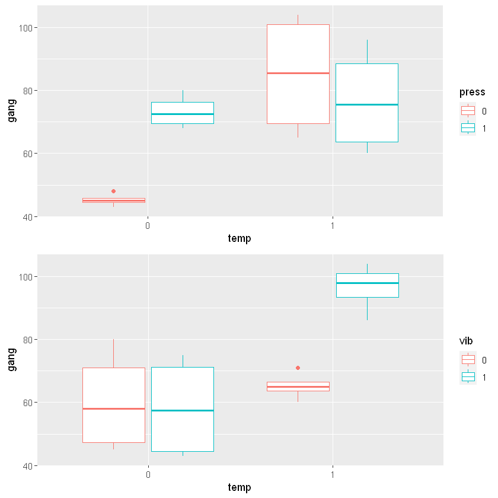

```r
p1 <- dat %>% ggplot() + geom_boxplot(aes(temp, gang, color = press))
p2 <- dat %>% ggplot() + geom_boxplot(aes(temp, gang, color = vib))
gridExtra::grid.arrange(p1, p2)
```

### 완전교락

- **교락법의 실험을 몇 회 반복할 때, 어느 반복에서나 똑같은 효과가 블록과 교락되는 것**
- **완전교락의 경우 교락된 요인에 대한 정보는 충분히 얻을 수 없지만,**

  **모든 요인의 효과는 블록효과와 교락되어 있지 않으므로, 충분한 정보를 얻을 수 있음**

#### 완전교락 예시

- **[반복 1]**
  - **[블록 1 : ac, (1), ab, bc] / [블록 2 : a, c, abc, b] $\rightarrow$ ABC교락**
- **[반복 2]**
  - **[블록 1 : c, abc, b, a] / [블록 2 : (1), ac, bc, ab] $\rightarrow$ ABC교락**
- **[반복 3]**
  - **[블록 1 : ab, (1), ac, bc] / [블록 2 : c, b, abc, a] $\rightarrow$ ABC교락**
- **하지만, 특정한 요인의 효과가 계속 블록효과와 교락되는 것이 싫은 경우**

  (그 요인의 효과에 대한 정보도 충분하지는 않지만 일부라도 알 고 싶은 경우)

  **반복마다 교락을 다르게 하는 부분교락 사용**

#### 부분교락 예시

- **[반복 1]**
  - **[블록 1 : abc, a, b, c] / [블록 2 : ab, ac, bc, (1)] $\rightarrow$ ABC교락**
- **[반복 2]**
  - **[블록 1 : abc, ac, b, (1)] / [블록 2 : ab, bc, a, c] $\rightarrow$ AC교락**
- **[반복 3]**
  - **[블록 1 : abc, bc, a, (1)] / [블록 2 : ab, ac, b, c] $\rightarrow$ BC교락**

## 08.03. $2^{n-p}$형 일부실시법

- **$2^n$요인배치법에서 고차의 상호작용효과를 희생시켜, 실험의 횟수를 줄일 필요 존재 $\rightarrow$ 일부실시법 (부분요인배치법, fractional factorial design)**
  - 특히 요인의 수가 많은 경우에 사용

#### $2^3$요인배치법에서의 교락법 예시

- **[블록 1 : a, b, c, abc] / [블록 2: (1), ab, ac, bc] $\rightarrow$ ABC가 블록효과와 교락**

  **두 블록 중 하나의 블록에서만 실험 $\rightarrow$ $2^{3-1}$회의 실험 실시**

#### 블록 1의 요인효과

$$A = {1\over 2}(a+abc-b-c) = BC$$$$B = {1\over 2}(b+abc-a-c) = AC$$$$C = {1\over 2}(c+abc-a-b) = AB$$

와 같아서

**주효과 A, B, C는, 2요인 상호작용 BC, AC, AB와 동일해져 교락됨 $\rightarrow$ 이와 같은 관계를 별명(alias)관계**

#### 별명관계

- 어느 요인의 효과가 서로 별명관계에 있느냐는 정의대비에 요인효과를 곱함으로 써 파악
  - 정의대비가 $I = ABC$일 때,

    $$A \times I = A \times (ABC) = A^2BC = BC$$

    $$B \times I = A \times (ABC) = AB^2C = AC$$

    $$C \times I = A \times (ABC) = ABC^2 = AB$$

**이와 같이 $2^3$요인배치법에서 1/2번만 실험을 실시하는 경우, 주효과와 상호작용효과가 교락되어 있으므로, 2요인간 상호작용효과가 충분히 무시될 수 있는 경우메나 주효과가 의미를 가짐**

일반적으로 일부실시법은 요인의 수가 많은 경우 사용되므로, 주효과나 2요인 간의 상호작용효과의 별명이 3차 이상의 고차 상호작용효과가 되도록 배치하는 것이 바람직

- **블록 1 대신 블록 2를 선택하여 1/2번 실험하는 경우**

$$A = {1\over 2}(ab+ac-bc-(1))=-BC$$$$B ={1\over 2} (ab+bc-ac-(1)) = -AC$$$$C ={1\over 2} (ac+bc-ab-(1))=-AB$$

- **2요인간 상호작용효과가 무시될 경우에는 어느 블록을 선택하여 실험해도 주효과의 파악에는 문제가 없지만**

  **그렇지 않는 경우에는 문제가 발생**

  (블록 1을 선택하였을 때 A의 주효과는 과대평가 / 블록 2를 선택하였을 때 A의 주효과는 과소평가)

#### 제품강도 예시

- 온도 A, 습도 B, 압력 C, 진동 D 네 요인이 제품의 강도에 미치는 영향 조사
- $2^4$요인배치법에서 16회 실험이 너무 많아 정의대비 $I=ABCD$를 사용하여 2개의 블록으로 나누어 일부실시법을 적용한 결과 ($2^{4-1}$)

[output not shown]

- 별명관계 ($I=ABCD$)

$A=BCD,\;\; B=ACD\;\;C=ABD\;\;D=ABC\;\;AB=CD\;\;AC=BD\;\;AD=BC$

```r
gang <- c(95.29, NA, NA, 86.58, NA, 88.7, 86.79, NA, NA, 96.45, 89.38, NA, 90.35, NA, NA, 89.57)
temp <- c(0, 1, 0, 1, 0, 1, 0, 1, 0, 1, 0, 1, 0, 1, 0, 1) %>% factor
humid <- c(0, 0, 1, 1, 0, 0, 1, 1, 0, 0, 1, 1, 0, 0, 1, 1) %>% factor
press <- c(0, 0, 0, 0, 1, 1, 1, 1, 0, 0, 0, 0, 1, 1, 1, 1) %>% factor
vib <- c(0, 0, 0, 0, 0, 0, 0, 0, 1, 1, 1, 1, 1, 1, 1, 1) %>% factor
dat = tibble(gang, temp, humid, press, vib)
```

- 변동을 계산한 후 두 요인 간 상호작용효과가 비교적 약한 AB, AC를 풀링 (변수에서 제거)

```r
anova <- aov(gang ~ temp + humid + press + vib + temp*vib + temp*humid + temp*press, dat)
tidy(anova)
```

A tibble: 7 × 4

| term <chr> | df <dbl> | sumsq <dbl> | meansq <dbl> |
| --- | --- | --- | --- |
| temp | 1 | 0.0325125 | 0.0325125 |
| humid | 1 | 42.6426125 | 42.6426125 |
| press | 1 | 18.8805125 | 18.8805125 |
| vib | 1 | 8.7990125 | 8.7990125 |
| temp:vib | 1 | 21.4185125 | 21.4185125 |
| temp:humid | 1 | 0.0276125 | 0.0276125 |
| temp:press | 1 | 0.9591125 | 0.9591125 |

- 풀링 결과, 주효과로는 요인 B (또는 ACD), C(또는 ABD), AD(또는 BC)가 유의함

```r
anova <- aov(gang ~ temp + humid + press + vib + temp*vib, dat)
tidy(anova)
```

A tibble: 6 × 6

| term <chr> | df <dbl> | sumsq <dbl> | meansq <dbl> | statistic <dbl> | p.value <dbl> |
| --- | --- | --- | --- | --- | --- |
| temp | 1 | 0.0325125 | 0.0325125 | 0.06589982 | 0.82139752 |
| humid | 1 | 42.6426125 | 42.6426125 | 86.43261800 | 0.01137271 |
| press | 1 | 18.8805125 | 18.8805125 | 38.26904659 | 0.02514921 |
| vib | 1 | 8.7990125 | 8.7990125 | 17.83478173 | 0.05175582 |
| temp:vib | 1 | 21.4185125 | 21.4185125 | 43.41333705 | 0.02226789 |
| Residuals | 2 | 0.9867250 | 0.4933625 | NA | NA |

- A가 $A_0$일 떄에는 $D_0$가 최적, A가 $A_1$일 때에는 $D_1$이 최적

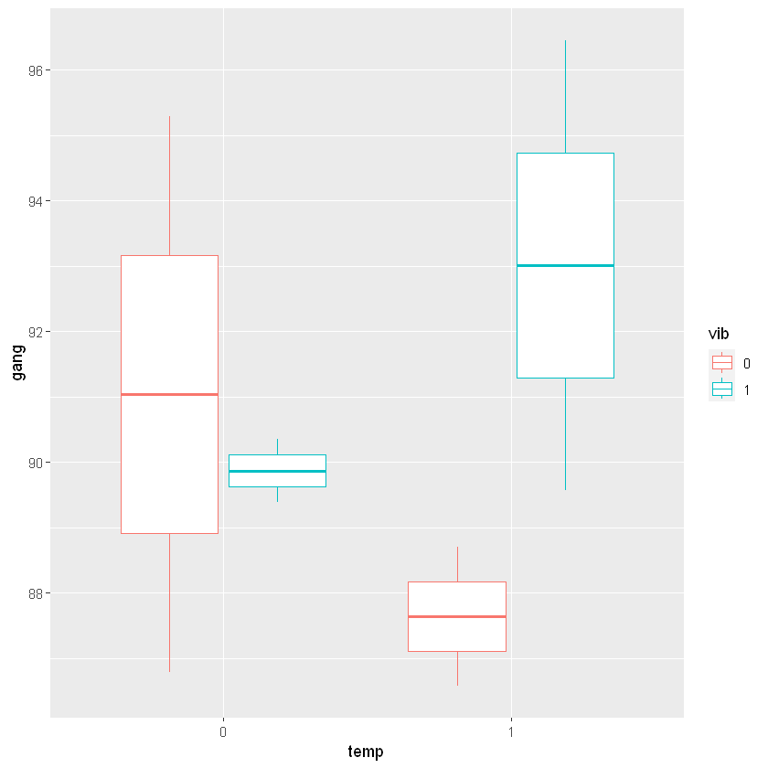

```r
dat %>% ggplot(aes(temp, gang, color = vib)) + geom_boxplot()
```

### $2^{n-2}$일부실시법

- **전체 실험의 1/4만 할 경우**
  - 4개의 블록에 처리조합들을 배치한 후 한 블록에서 실험

#### $2^5$요인배치법 예시

$$I = ACE = BDE = ABCD$$$$L_1 = x_1 + x_3 + x_5(mod2)$$$$L_2 = x_2 + x_4 + x_5(mod2)$$$$L_3 = x_1 + x_2 + x_3 + x_4(mod2)$$

가 되며

처리조합에 대한 $L_1$과 $L_2$는

| 처리조합 | L1 | L2 | 처리조합 | L1 | L2 |
| --- | --- | --- | --- | --- | --- |
| (1) | 0 | 0 | e | 1 | 1 |
| $\vdots$ | $\vdots$ | $\vdots$ | $\vdots$ | $\vdots$ | $\vdots$ |
| abcd | 0 | 0 | abcde | 1 | 1 |

가 되며 $2^5=32$개의 처리조합을 4개의 블록으로 나누면

**[블록 1 : (1), ac, bd, abe, ade, bce, cde, abcd], $\rightarrow$ $L_1=0, L_2=0$**

**[블록 2 : b, abc, d, acd, ae, ce, abde, bcde], $\rightarrow$ $L_1=0, L_2=1$**

**[블록 3 : a, c, abd, bcd, be, abce, de, acde], $\rightarrow$ $L_1=1, L_2=0$**

**[블록 4 : ab, bc, ad, cd, e, ace, bde, abcde], $\rightarrow$ $L_1=1, L_2=1$**

#### 별명관계

$$A=CE=ABDE=BCD$$$$B=ABCE=DE=ACD$$$$C=AE=BCDE=ABD$$$$D=ACDE=BE=ABC$$$$E=AC=BD=ABCDE$$$$AB=BCE=ADE=CD$$$$AD=CDE=ABE=BC$$

- 어떤 블록을 선택해 실험해도 2차 이상의 상호작용효과를 무시할 수 있다면, $2^{5-2}=8$번의 실험으로도 주효과 A, B, C, D, E를 추정할 수 있음

#### 일부실시법에서는 교락시키는 요인의 선택에 주의

- $2^{5-2}$일부실시법에서 ABCDE와 ABC를 교락요인으로 선택하는 경우, 정의대비는

$$I = ABCDE = ABC=DE$$

가 도어

결과적으로

$$D=ABCE=ABCD=E$$

가 되어 주효과 D와 주효과 E가 교락됨

- **따라서, 관심있는 주효과들끼리 교락이 되지 않도록 설계 해야함**